# Reproducible Research: Peer Assessment 1

## Loading and preprocessing the data

First, we open the zip file and load the .csv contained inside.

```r
data <- read.csv(unzip("activity.zip"))
data$date <- as.Date(data$date)
summary(data)
```

```
##      steps             date               interval
##  Min.   :  0.00   Min.   :2012-10-01   Min.   :   0.0
##  1st Qu.:  0.00   1st Qu.:2012-10-16   1st Qu.: 588.8
##  Median :  0.00   Median :2012-10-31   Median :1177.5
##  Mean   : 37.38   Mean   :2012-10-31   Mean   :1177.5
##  3rd Qu.: 12.00   3rd Qu.:2012-11-15   3rd Qu.:1766.2
##  Max.   :806.00   Max.   :2012-11-30   Max.   :2355.0
##  NA's   :2304
```

## What is mean total number of steps taken per day?

We can use the aggregate function to total up the number of steps per day, call a histogram on the step data, and then look at the summary function to see at the mean and median for the daily data.

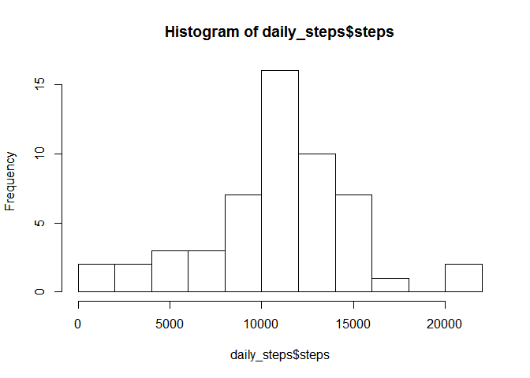

```r
daily_steps <- aggregate(steps ~ date, data = data, sum)
hist(daily_steps$steps, breaks=10)
```

```r
summary(daily_steps$steps)
```

```
##    Min. 1st Qu.  Median    Mean 3rd Qu.    Max.
##      41    8841   10760   10770   13290   21190
```

## What is the average daily activity pattern?

We can again use the aggregate function to get an average number of steps per time interval, and plot the data with a time series plot.

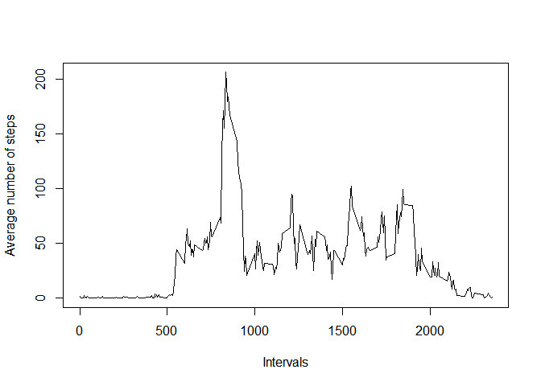

```r
daily_activity <- aggregate(steps ~ interval, data = data, mean)
plot(daily_activity$interval, daily_activity$steps, type="l", xlab="Intervals", ylab="Average number of steps")
```

We can then find the interval with the number of stpes

```r
daily_activity$interval[[which.max(daily_activity$steps)]]
```

```
## [1] 835
```

## Imputing missing values

We can find the number of missing values by using the complete.cases() function.

```r
sum(!complete.cases(data))
```

```
## [1] 2304
```

We can then fill in these NAs by using the mean data for that interval.

```r
for (row in 1:nrow(data)) {
  if (is.na(data[row, ]$steps)) {
    data[row, ]$steps <- daily_activity$steps[[which(daily_activity$interval == data[row, ]$interval)]]
  }
}
```

Finally, we can remake the histogram and summary like in part 1, and compare and contrast.

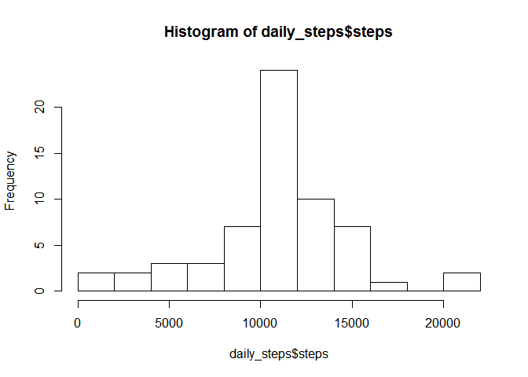

```r
daily_steps <- aggregate(steps ~ date, data = data, sum)
hist(daily_steps$steps, breaks=10)
```

```r
summary(daily_steps$steps)
```

```
##    Min. 1st Qu.  Median    Mean 3rd Qu.    Max.
##      41    9819   10770   10770   12810   21190
```

## Are there differences in activity patterns between weekdays and weekends?

We can make a new factor variable by using the weekdays() function. In the data loading process, we already converted the date column into Date objects.

```r
data$weekday <- rep(NA, nrow(data))
for(row in 1:nrow(data)) {
  if((weekdays(data$date[[ row]]) == "Saturday") || (weekdays(data$date[[ row]]) == "Sunday")) {
    data$weekday[[ row]] <- "weekend"
  } else {
    data$weekday[[ row]] <- "weekday"
  }
}
data$weekday <- as.factor(data$weekday)
table(data$weekday)
```

```
##
## weekday weekend
##   12960    4608
```